# Spatial data science with R

Violeta Sosa

May 22 2019

## Exercises for Meeting May 24 2019

Work on the exercise for Data Cubes Exercises described in https://keen-swartz-3146c4.netlify.com/raster.html#exercises-2

## Exercise 1

NDVI, normalized differenced vegetation index, is computed as `(NIR-R)/(NIR+R)`, with NIR the near infrared and R the red band. Read the `L7_ETMs.tif` file into object `x`, and distribute the band dimensions over attributes by `split(x, "band")`. Then, compute NDVI by using an expression that uses the NIR (band 4) and R (band 3) attributes directly.

```r
tif = system.file("tif/L7_ETMs.tif", package = "stars")
library(stars)
library(sf)
x = read_stars(tif)
x
```

```
## stars object with 3 dimensions and 1 attribute
## attribute(s):
##   L7_ETMs.tif
##  Min.   :  1.00
##  1st Qu.: 54.00
##  Median : 69.00
##  Mean   : 68.91
##  3rd Qu.: 86.00
##  Max.   :255.00
## dimension(s):
##      from  to  offset delta                       refsys point values
## x       1 349  288776  28.5 +proj=utm +zone=25 +south... FALSE   NULL [x]
## y       1 352 9120761 -28.5 +proj=utm +zone=25 +south... FALSE   NULL [y]
## band    1   6      NA    NA                           NA    NA   NULL
```

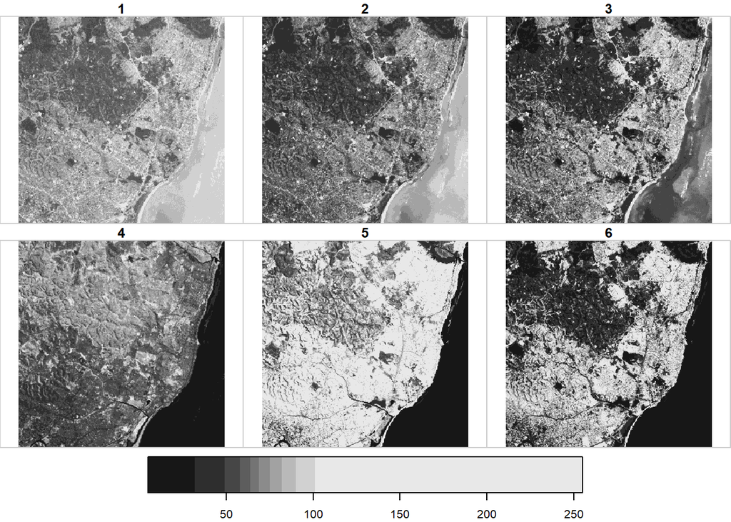

```r
plot(x)
```

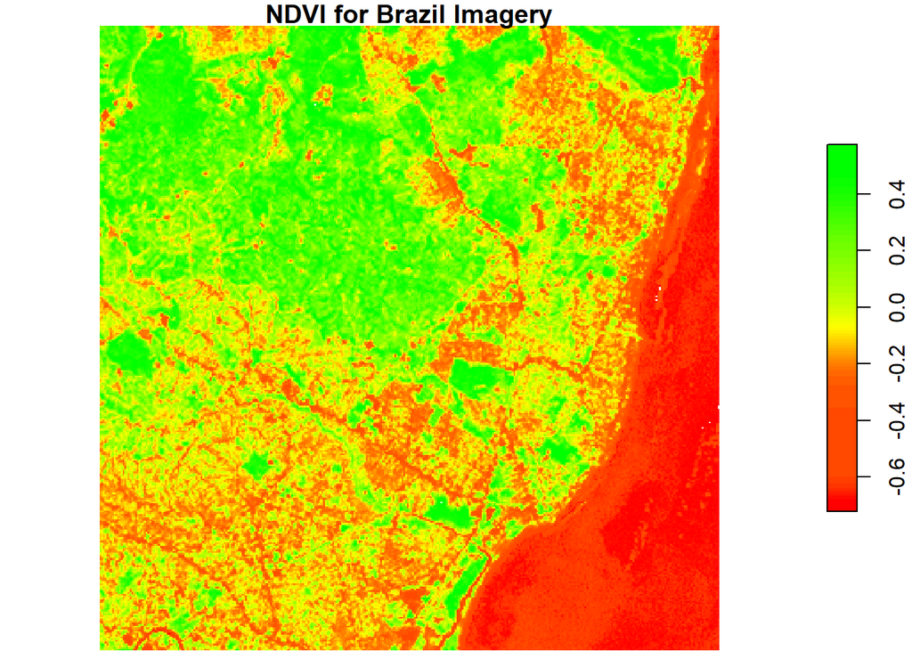

```r
per_band=split(x, "band")

ndvi_brazil <- (per_band[4,] - per_band[3,]) / (per_band[4,] + per_band[3,])
plot(ndvi_brazil,col=colorRampPalette(c("red","yellow","green"))(50),main="NDVI for Brazil Imagery")
```

## Exercise 2

Compute NDVI for the S2 image, using `st_apply` and an a function `ndvi = function(x) (x[4]-x[3])/(x[4]+x[3])`. Plot the result, and write the result to a GeoTIFF. Explain the difference in runtime between plotting and writing.

```r
#WARNING!

#The next file size is around 1GB. Uncomment the line if you DO NOT already have the file in your local machine!

#install.packages("starsdata", repos = "http://pebesma.staff.ifgi.de", type = "source")

granule = system.file("sentinel/S2A_MSIL1C_20180220T105051_N0206_R051_T32ULE_20180221T134037.zip", package = "starsdata")
base_name = strsplit(basename(granule), ".zip")[[1]]
s2 = paste0("SENTINEL2_L1C:/vsizip/", granule, "/", base_name, ".SAFE/MTD_MSIL1C.xml:10m:EPSG_32632")
(p = read_stars(s2, proxy = TRUE))
```

```
## stars_proxy object with 1 attribute in file:
## $`MTD_MSIL1C.xml:10m:EPSG_32632`
## [1] "SENTINEL2_L1C:/vsizip/C:/Users/Violet/Documents/R/win-library/3.5/starsdata/sentinel/S2A_MSIL1C_20180220T105051_N0206_R051_T32ULE_20180221T134037.zip/S2A_MSIL1C_20180220T105051_N0206_R051_T32ULE_20180221T134037.SAFE/MTD_MSIL1C.xml:10m:EPSG_32632"
##
## dimension(s):
##      from    to offset delta                       refsys point values
## x       1 10980  3e+05    10 +proj=utm +zone=32 +datum...    NA   NULL [x]
## y       1 10980  6e+06   -10 +proj=utm +zone=32 +datum...    NA   NULL [y]
## band    1     4     NA    NA                           NA    NA   NULL
```

```r
ndvi = function(x) (x[4]-x[3])/(x[4]+x[3])
ndvi_s2<-st_apply(p, c("x", "y"), ndvi)
plot(ndvi_s2, col=colorRampPalette(c("red","yellow","green"))(50),main="NDVI for Sentinel Imagery")

start.time <- Sys.time()
write_stars(p, "p2.tif")
end.time <- Sys.time()
time.takenG <- end.time - start.time
time.takenG
```

```
## Time difference of 1.983504 mins
```

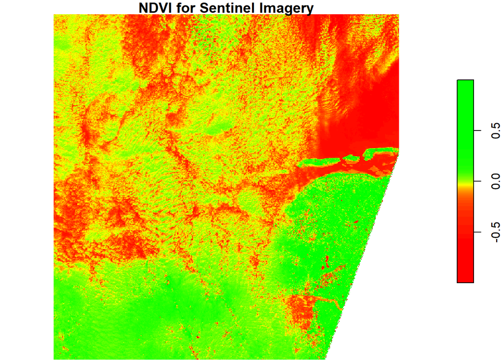

```r
start.time <- Sys.time()
plot(ndvi_s2, col=colorRampPalette(c("red","yellow","green"))(50),main="NDVI for Sentinel Imagery")
```

```r
end.time <- Sys.time()
time.takenP <- end.time - start.time
time.takenP
```

```
## Time difference of 7.168569 secs
```

*The time for the GeoTIFF generation is `1.98350378274918 mins` and for the plot `7.16856908798218 secs`. These differences are because of the pixel size and image resolution for the outputs. Meanwhile, the plot shows a basic result that renders according to zoom levels, the TIFF image (apart from all the metadata stored?) contains the complete resolution values for the image.*

## Exercise 3

Use `st_transform` to transform the `stars` object read from `L7_ETMs.tiff` to EPSG 4326. Print the object. Is this a regular grid? Plot the first band using arguments `axes=TRUE` and `borders=NA`, and explain why this takes such a long time.

```r
l7_transform<-st_transform(x,crs =4326)
l7_transform
```

```
## stars object with 3 dimensions and 1 attribute
## attribute(s):
##   L7_ETMs.tif
##  Min.   :  1.00
##  1st Qu.: 54.00
##  Median : 69.00
##  Mean   : 68.91
##  3rd Qu.: 86.00
##  Max.   :255.00
## dimension(s):
##      from  to offset delta                       refsys point
## x       1 349     NA    NA +proj=longlat +datum=WGS8... FALSE
## y       1 352     NA    NA +proj=longlat +datum=WGS8... FALSE
## band    1   6     NA    NA                           NA    NA
##                               values
## x    [349x352] -34.9165,...,-34.8261 [x]
## y     [349x352] -8.0408,...,-7.94995 [y]
## band                            NULL
## curvilinear grid
```

*It is not a regular grid. It is a curvilinear grid.*

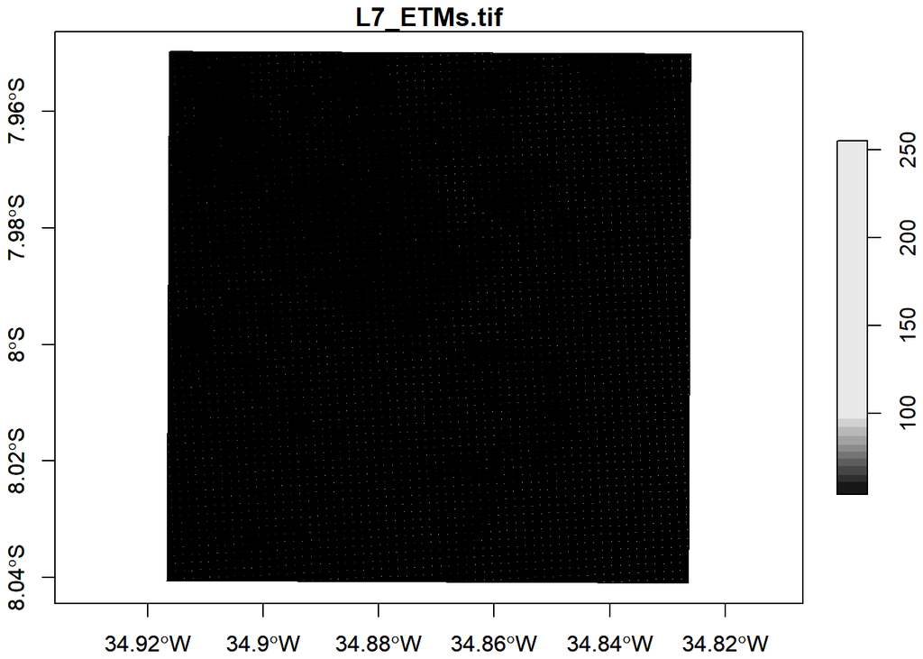

```r
start.time <- Sys.time()
plot(l7_transform[,,,1],axes=TRUE,borders=NA)
```

```r
end.time <- Sys.time()
time.takenL7 <- end.time - start.time
time.takenL7
```

```
## Time difference of 34.45923 secs
```

*The computing time for this occasion is `34.4592349529266 secs`. It takes much time because of the computation of the values for each pixel to render it properly in a lower resolution by scaling the result to fit the user screen. First time running the exercise in local machine took **2 minutes**, the second time around 15 seconds, this may be due to the cache store in the workspace.*

## Exercise 4

Use `st_warp` to warp the `L7_ETMs.tif` object to EPSG 4326, and plot the resulting object with `axes=TRUE`. Why is the plot created much faster than after `st_transform`?

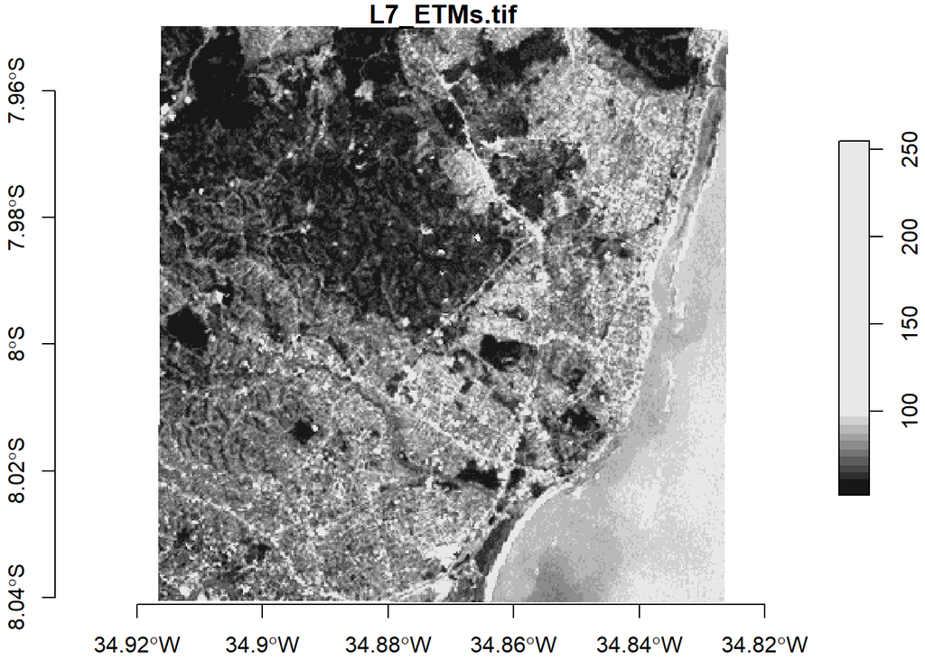

```r
warp_trans<-st_warp(x,crs=4326)
plot(warp_trans[,,,1],axes=TRUE,borders=NA)

start.time <- Sys.time()
plot(warp_trans[,,,1],axes=TRUE,borders=NA)
```

```r
end.time <- Sys.time()
time.takenwarp <- end.time - start.time
time.takenwarp
```

```
## Time difference of 2.156435 secs
```

*This plot is much faster, it only took `2.1564347743988 secs`. This is because the `st_transform` function leads to `lossless transformation`[3]. It keeps the image data integration: **For gridded spatial data, a curvilinear grid with a transformed grid cell (centers) is returned** [3]. In the other hand, `st_wraps` converts the object into a regular grid in the new CRS. The `st_wraps` function implies a **resampling is done over the image, causing the loss of data that can not be reversed**[3].*

## References

[[1] Spatial Data Science.Edzer Pebesma, Roger Bivand](https://keen-swartz-3146c4.netlify.com/raster.html)

[[2] R Spatial: Plotting and subsetting stars objects](https://www.r-spatial.org/r/2018/03/22/stars2.html)

[[3] R Stars Library Documentation](https://r-spatial.github.io/stars/reference/st_transform.html)